# Assignment 5: Dimensionality reduction

## Brief from moodle

> Actually, a fairly large selection of statistical methods can be listed under the title “dimensionality reduction techniques”. Most often (nearly always, that is!) the real-world phenomena are multidimensional: they may consist of not just two or three but 5 or 10 or 20 or 50 (or more) dimensions. Of course, we are living only in a three-dimensional (3D) world, so those multiple dimensions may really challenge our imagination. It would be easier to reduce the number of dimensions in one way or another.

> We shall now learn the basics of two data science based ways of reducing the dimensions. The principal method here is principal component analysis (PCA), which reduces any number of measured (continuous) and correlated variables into a few uncorrelated components that collect together as much variance as possible from the original variables. The most important components can be then used for various purposes, e.g., drawing scatterplots and other fancy graphs that would be quite impossible to achieve with the original variables and too many dimensions.

> Multiple correspondence analysis (MCA) and other variations of CA bring us similar possibilities in the world of discrete variables, even nominal scale (classified) variables, by finding a suitable transformation into continuous scales and then reducing the dimensions quite analogously with the PCA. The typical graphs show the original classes of the discrete variables on the same “map”, making it possible to reveal connections (correspondences) between different things that would be quite impossible to see from the corresponding cross tables (too many numbers!).

> Briefly stated, these methods help to visualize and understand multidimensional phenomena by reducing their dimensionality that may first feel impossible to handle at all.

### 0. Setup, read the data

```r
library(readr)
library(tibble)
library(GGally)
```

```r
library(corrplot)
human0 <- read_csv("https://raw.githubusercontent.com/KimmoVehkalahti/Helsinki-Open-Data-Science/master/datasets/human2.csv", show_col_types = FALSE)
```

```
## `curl` package not installed, falling back to using `url()`
```

## 1. Country names as rownames + summaries

- `Move the country names to rownames (see Exercise 5.5).`
- `Show a graphical overview of the data and show summaries of the variables in the data.`
- `Describe and interpret the outputs, commenting on the distributions of the variables and the relationships between them.` (0-3 points)

### Rownames

```r
human <- column_to_rownames(human0, "Country")
```

### Summary, statistics

Let’s look at the data, starting with some descriptive statistics:

```r
summary(human)
```

```
##     Edu2.FM          Labo.FM          Life.Exp        Edu.Exp
##  Min.   :0.1717   Min.   :0.1857   Min.   :49.00   Min.   : 5.40
##  1st Qu.:0.7264   1st Qu.:0.5984   1st Qu.:66.30   1st Qu.:11.25
##  Median :0.9375   Median :0.7535   Median :74.20   Median :13.50
##  Mean   :0.8529   Mean   :0.7074   Mean   :71.65   Mean   :13.18
##  3rd Qu.:0.9968   3rd Qu.:0.8535   3rd Qu.:77.25   3rd Qu.:15.20
##  Max.   :1.4967   Max.   :1.0380   Max.   :83.50   Max.   :20.20
##       GNI            Mat.Mor         Ado.Birth         Parli.F
##  Min.   :   581   Min.   :   1.0   Min.   :  0.60   Min.   : 0.00
##  1st Qu.:  4198   1st Qu.:  11.5   1st Qu.: 12.65   1st Qu.:12.40
##  Median : 12040   Median :  49.0   Median : 33.60   Median :19.30
##  Mean   : 17628   Mean   : 149.1   Mean   : 47.16   Mean   :20.91
##  3rd Qu.: 24512   3rd Qu.: 190.0   3rd Qu.: 71.95   3rd Qu.:27.95
##  Max.   :123124   Max.   :1100.0   Max.   :204.80   Max.   :57.50
```

Based on the difference between mean and median, and the ranges of the variables, `Edu.Exp` and `Parli.FM` seem the most normally distributed. `Edu2.FM`, `Labo.FM` and `Life.Exp` are more skewed or have long tails (bdifference between mean and median, and the ranges of the variables). `GNI` and `Mat.Mor` are closer to log-normal (or a related distribution), and maybe `Ado.Birth` as well.

### Summary, graphical

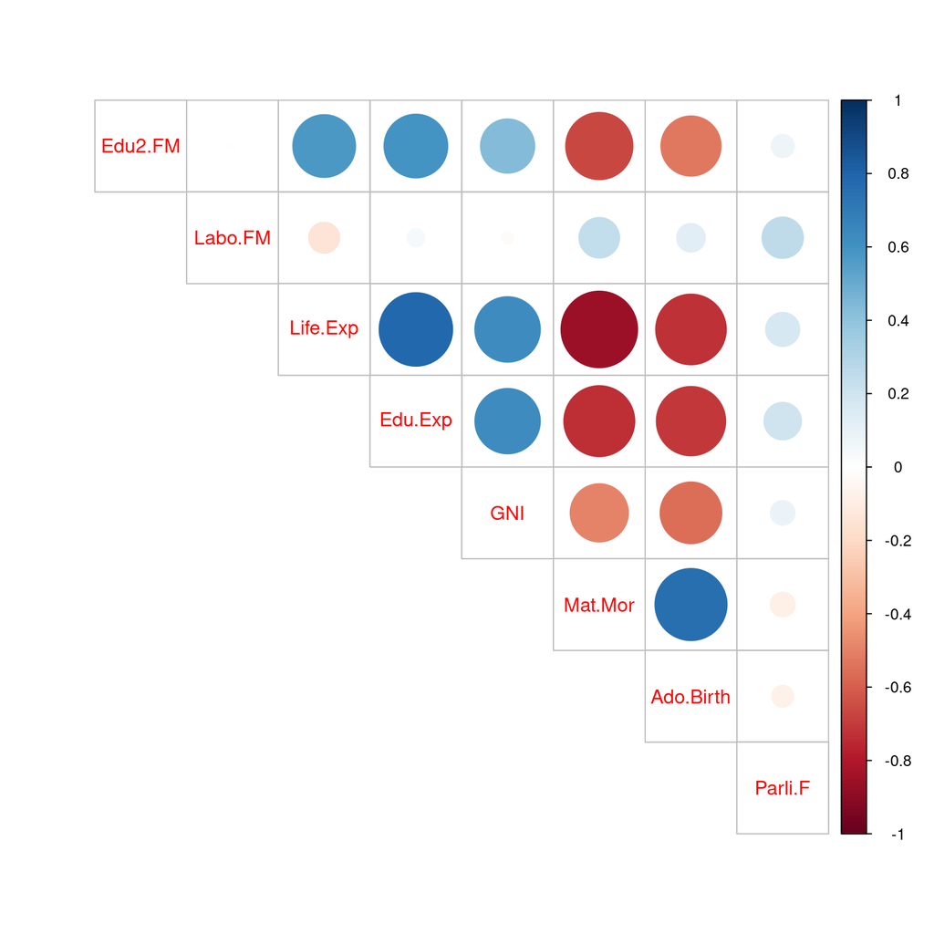

fig. 1.1, correlation matrix of variables

```r
corrplot(cor(human), method="circle",type = "upper", tl.pos = "d")
```

First, there is one set of *very* strongly correlated variables: `Mat.Mor`, `Ado.Birth`, `Life.Exp`, and `Edu.Exp`. These will likely be very strongly represented in the first principal component of a PCA.

Second, these four variables also correlate very strongly with `GNI` and `Edu2.FM`, more strongly than that pair of variables correlate between themselves. Since they correlate less amongst themselves, there seems to be more degrees of freedom here.

Then there is a third group, `Labo.FM` and `Parli.F`. They seem much less correlated compared to the other set of variables, however, they are most strongly correlated with each other. Again, seemingly more degrees of freedom in this group.

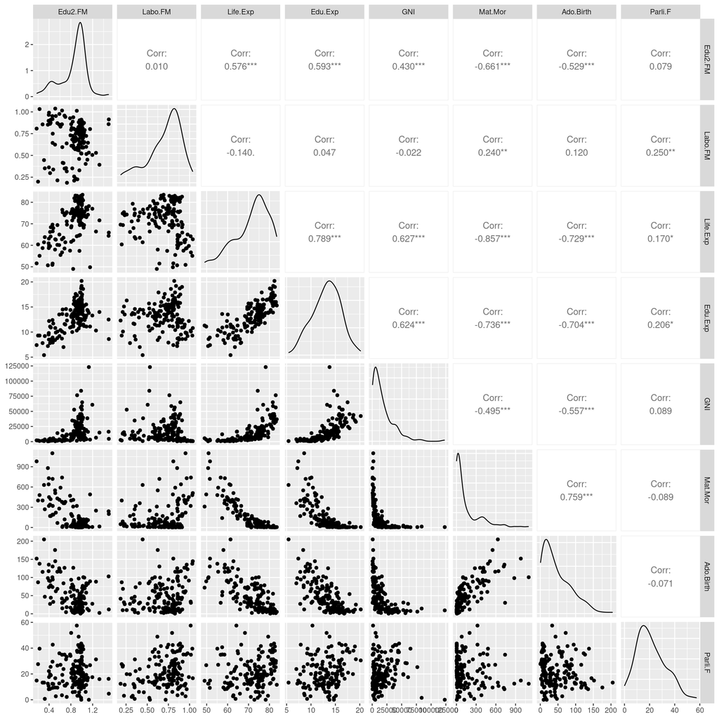

fig. 1.2, distributions and scatterplots of variables

```r
ggpairs(human, progress = FALSE)
```

The correlations become much more clear when looking at the scatterplots. Some are clearly linear, like `Edu.Exp` and `Life.Exp`. It’s even clearer that `GNI` might need to be log-transformed, based on the distribution and the scatter plot shapes. Possibly `Mat.Mor` and `Ado.Birth` too.

The other distributions look like skewed normal-like distributions, all of them have one big main mode, although there are some interesting concentrations in certain parts of the distributions.

E.g., in `Life.Exp`, there is a clear plateau from 60 to roughly 65 or so. This may be related to quality of life before and after retirement.

Another example is this curious smaller mode in the `Edu2.FM` around 0.5, and a subsequent drop after that. This suggests that there are two overlaid populations, one where the mode is a little under 1, another where the mode is around 0.5. I don’t have a hypothesis for what could be causing this difference in behaviors in the two populations of countries, but it’s a very interesting feature of the distribution. Unfortunately we’ve already thrown away the two variables that this variable is based on, which may have given us some clues to what this effect is.

## 2. PCA with raw data

- `Perform principal component analysis (PCA) on the raw (non-standardized) human data.`
- `Show the variability captured by the principal components.`
- `Draw a biplot displaying the observations by the first two principal components (PC1 coordinate in x-axis, PC2 coordinate in y-axis), along with arrows representing the original variables.` (0-2 points)

## 3. PCA with standardized variables

- `Standardize the variables in the human data and repeat the above analysis.`
- `Interpret the results of both analysis (with and without standardizing).`
- `Are the results different? Why or why not? Include captions (brief descriptions) in your plots where you describe the results by using not just your variable names, but the actual phenomena they relate to.` (0-4 points)

## 4. Interpret biplot

- `Give your personal interpretations of the first two principal component dimensions based on the biplot drawn after PCA on the standardized human data.` (0-2 points)

## 5. MCA on tea data

> The tea data comes from the FactoMineR package and it is measured with a questionnaire on tea: 300 individuals were asked how they drink tea (18 questions) and what are their product’s perception (12 questions). In addition, some personal details were asked (4 questions).

> Load the tea dataset and convert its character variables to factors:

> tea <- read.csv(“https://raw.githubusercontent.com/KimmoVehkalahti/Helsinki-Open-Data-Science/master/datasets/tea.csv”, stringsAsFactors = TRUE)
- `Explore the data briefly: look at the structure and the dimensions of the data. Use View(tea) to browse its contents, and visualize the data.`
- `Use Multiple Correspondence Analysis (MCA) on the tea data (or on just certain columns of the data, it is up to you!).`
- `Interpret the results of the MCA and draw at least the variable biplot of the analysis. You can also explore other plotting options for MCA.`
- `Comment on the output of the plots.` (0-4 points)